# Alaa Hamid

## Notes Before Begining.

### a). Setting Up the Evnvironment through out these commands:

1. uv venv --python 3.13.9 # setting up the environment.  
2. uv add *Lib_name* # adding the required libraries using.  
3. uv init # initiate the environment.  
4. Create and open a note book (.ipynb)

b). Understanding the Business Problem:

To Study and Understand  
1. The types of cars preferred by the customers.  
2. The Factores influencing the car purchase.  
3. Understand the cars market in U.S.A

Aims of the Analysis:

1. understand the dynamics of a new market.
2. identify new purchase ooportunities

Key Questions:

- How old are most of our customers, (what age do we attract as acompany)?
- Waht gender is the most domenant?
- how wealthy are our Customers?
- are dependants going along with car size?
- Relationship betweeen dependants and car value and family income.

# 1. Data Exploration:

```python
# Importing all the necessary Libraries to the note book:

import pandas as pd
import seaborn as sns
import matplotlib.pyplot as plt
import numpy as np
```

```python
# Readin the file:

df = pd.read_csv("austo_automobile.csv")
df.head()
```

|  | Age | Gender | Profession | Marital_status | Education | No_of_Dependents | Personal_loan | House_loan | Partner_working | Salary | Partner_salary | Total_salary | Price | Make |
| --- | --- | --- | --- | --- | --- | --- | --- | --- | --- | --- | --- | --- | --- | --- |
| 0 | 24 | Male | Salaried | Married | Post Graduate | 4 | No | Yes | Yes | 52000 | 25000 | 77000 | 18000 | Hatchback |
| 1 | 28 | Male | Salaried | Married | Post Graduate | 3 | No | Yes | No | 68000 | 0 | 68000 | 18000 | Hatchback |
| 2 | 23 | Male | Salaried | Married | Graduate | 4 | Yes | Yes | No | 31000 | 0 | 31000 | 18000 | Hatchback |
| 3 | 26 | Male | Business | Married | Post Graduate | 4 | Yes | Yes | Yes | 66000 | 35000 | 101000 | 18000 | Hatchback |
| 4 | 28 | Male | Business | Married | Post Graduate | 4 | Yes | No | No | 64000 | 0 | 64000 | 18000 | Hatchback |

```python
# initial info. about the data

print(" The Shape of the data set is: ",df.shape)

print("\n The names of the columns of the data are: \n", df.columns)

print ("\nSome inital Description of the Data: ")
df.info()
```

```
 The Shape of the data set is:  (1581, 14)

 The names of the columns of the data are:
 Index(['Age', 'Gender', 'Profession', 'Marital_status', 'Education',
       'No_of_Dependents', 'Personal_loan', 'House_loan', 'Partner_working',
       'Salary', 'Partner_salary', 'Total_salary', 'Price', 'Make'],
      dtype='str')

Some inital Description of the Data:
<class 'pandas.DataFrame'>
RangeIndex: 1581 entries, 0 to 1580
Data columns (total 14 columns):
 #   Column            Non-Null Count  Dtype
---  ------            --------------  -----
 0   Age               1581 non-null   int64
 1   Gender            1581 non-null   str
 2   Profession        1581 non-null   str
 3   Marital_status    1581 non-null   str
 4   Education         1581 non-null   str
 5   No_of_Dependents  1581 non-null   int64
 6   Personal_loan     1581 non-null   str
 7   House_loan        1581 non-null   str
 8   Partner_working   1581 non-null   str
 9   Salary            1581 non-null   int64
 10  Partner_salary    1581 non-null   int64
 11  Total_salary      1581 non-null   int64
 12  Price             1581 non-null   int64
 13  Make              1581 non-null   str
dtypes: int64(6), str(8)
memory usage: 173.1 KB
```

### Findings from Step 1:

- Shape: The shape of the DataSet is 1581 rows and 14 columns (attributes or variables). This would be an initial indecation for any missing values in all Variables.
- Columns name: are all standarised with the first letter capitalised, striped and using undescore to connect the words.
- Data info: shows that the data has no missing values and the data type is correct for now (would be changed from Cat-> Num) further along.

# 2. Data Cleaning

Data type and ranges:

1. Categorical: Data type check and fix Categorical (turn into numerical if possible after EDA).
2. Numerical: Range check and fix for the Numerical Columns.
3. General Cleaning

### Categorical Cleaning:

The main thing with categorical variables cleanning

```python
#Selecting the categorical columns: (obj: string, categorical)
cat_cols = df.select_dtypes(include=["object", "category"]).columns
print("\n All the categorical columns: \n", cat_cols)

# Strip and standarise the values.

for i in cat_cols:
    df[i] = (
        df[i]
        .str.strip()  # Strip
        .str.lower()  # #lower_case
    )
```

```
 All the categorical columns:
 Index(['Gender', 'Profession', 'Marital_status', 'Education', 'Personal_loan',
       'House_loan', 'Partner_working', 'Make'],
      dtype='str')
```

```python
# Encoding (mapping) male an female into 0,1
print("Showing Gender Unique Values before mapping", df["Gender"].unique()) # showing the unique values in the column (male, female)

#df["Gender"] = df["Gender"].map({
  #  'male': 1,
  #  'female': 0

 #   })                        # (male -> 1) , (female -> 0)

print(df["Gender"].unique()) # showing the unique values in the column (male, female)
```

```
Showing Gender Unique Values before mapping <StringArray>
['male', 'female']
Length: 2, dtype: str
<StringArray>
['male', 'female']
Length: 2, dtype: str
```

```python
#Check if there are any missing data:
df.isna().sum() # SHowing no missing DAta
```

```
Age                 0
Gender              0
Profession          0
Marital_status      0
Education           0
No_of_Dependents    0
Personal_loan       0
House_loan          0
Partner_working     0
Salary              0
Partner_salary      0
Total_salary        0
Price               0
Make                0
dtype: int64
```

```python
# do that for the rest of the categorical values:

for col in cat_cols:
    if col != "Gender":
        df[col] = (
            df[col]
            .str.strip()
            .str.lower()

    )
```

```python
# Showing the unique values of each categorical column would help understand the values.
for i in cat_cols:
    print(f"\n Unique values in {i}: ")
    print(df[i].unique())
```

```
 Unique values in Gender:
<StringArray>
['male', 'female']
Length: 2, dtype: str

 Unique values in Profession:
<StringArray>
['salaried', 'business']
Length: 2, dtype: str

 Unique values in Marital_status:
<StringArray>
['married', 'single']
Length: 2, dtype: str

 Unique values in Education:
<StringArray>
['post graduate', 'graduate']
Length: 2, dtype: str

 Unique values in Personal_loan:
<StringArray>
['no', 'yes']
Length: 2, dtype: str

 Unique values in House_loan:
<StringArray>
['yes', 'no']
Length: 2, dtype: str

 Unique values in Partner_working:
<StringArray>
['yes', 'no']
Length: 2, dtype: str

 Unique values in Make:
<StringArray>
['hatchback', 'suv', 'sedan']
Length: 3, dtype: str
```

### Check for dublicated

```python
# No duplicates in the data set
df.duplicated().any()
```

```
np.False_
```

## Numerical Cleaning

```python
# Showing all the numerical columns in the Data Set:

num_cols = df.select_dtypes(include=["number"]).columns
print(num_cols)
df.select_dtypes(include = "number").dtypes
```

```
Index(['Age', 'No_of_Dependents', 'Salary', 'Partner_salary', 'Total_salary',
       'Price'],
      dtype='str')
```

```
Age                 int64
No_of_Dependents    int64
Salary              int64
Partner_salary      int64
Total_salary        int64
Price               int64
dtype: object
```

### Detecting Outliers:

```python
df.select_dtypes(include="number").describe()

# From looking at the descritption of the data it
# shows that there are no out of order values for now we can say there are no impossible results
```

|  | Age | No_of_Dependents | Salary | Partner_salary | Total_salary | Price |
| --- | --- | --- | --- | --- | --- | --- |
| count | 1581.000000 | 1581.000000 | 1581.000000 | 1581.000000 | 1581.000000 | 1581.000000 |
| mean | 32.211259 | 2.457938 | 59732.447818 | 19720.430108 | 79452.877925 | 35597.722960 |
| std | 9.125477 | 0.943483 | 14278.642665 | 19480.214404 | 24855.936043 | 13633.636545 |
| min | 22.000000 | 0.000000 | 30000.000000 | 0.000000 | 30000.000000 | 18000.000000 |
| 25% | 25.000000 | 2.000000 | 51000.000000 | 0.000000 | 61000.000000 | 25000.000000 |
| 50% | 29.000000 | 2.000000 | 59000.000000 | 25000.000000 | 78000.000000 | 31000.000000 |
| 75% | 38.000000 | 3.000000 | 71000.000000 | 38000.000000 | 96000.000000 | 47000.000000 |
| max | 60.000000 | 4.000000 | 90000.000000 | 80000.000000 | 158000.000000 | 70000.000000 |

## Univariate Analysis

In this section:

- Key data (cat & Numeric Would be analysed). using plots for better understanding.

### 1. Age of customers

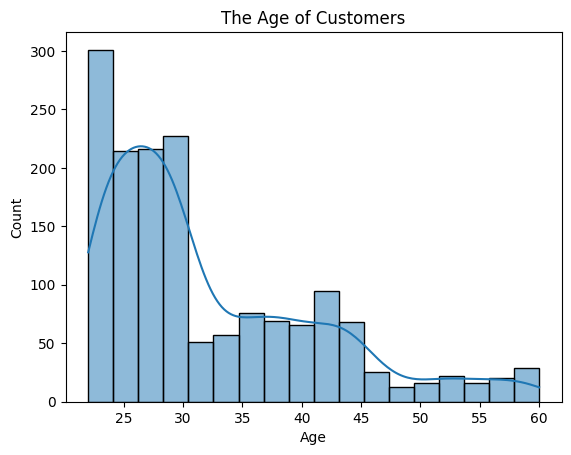

```python
# understand the age of the customers:
sns.histplot(df["Age"], kde=True)
plt.title("The Age of Customers")
plt.show()
```

### 2. Gender of customers:

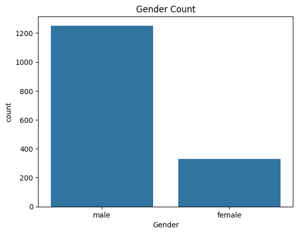

```python
# Showing the gender\Count using countplot:

sns.countplot(x= df["Gender"], data=df)
plt.title("Gender Count")
plt.show()
```

### Figure Findings:

male are more than female using the cars of this company

### 3. Salary Analysis

### What are the financial situation of the customers (income vs car type)

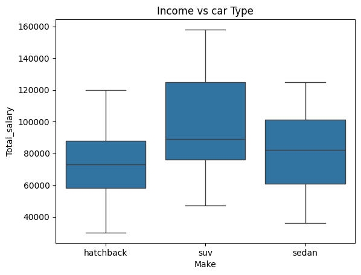

```python
sns.boxplot(x="Make", y="Total_salary", data=df)
plt.title("Income vs car Type")
```

### Figure Findings:

SUV: has the Highest Median income and higest Upper Income. Sedan: has Lower than SUV but higher than hatchback. Hatchback: has the lowest median income, tighter distrebution.

That means that SUV is more pupular with the wilthy customers

### salary Distrebution

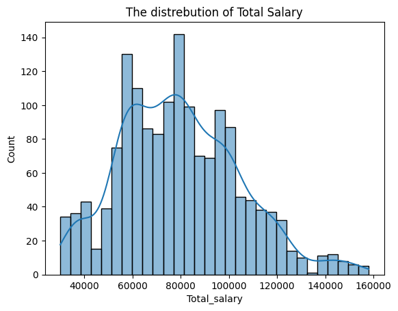

```python
# An Idea of the salary statistics ofthe customers
sns.histplot(df["Total_salary"],bins=30, kde=True)
plt.title("The distrebution of Total Salary")
plt.show()
```

### 4. Price Range:

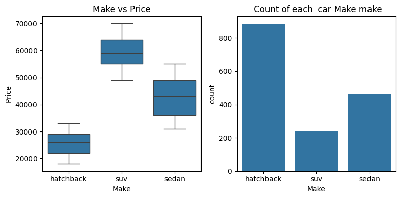

```python
# Price Range of the cars
plt.figure(figsize=(8,4))
plt.subplot(1,2,1)
sns.boxplot(x="Make", y="Price", data=df)
plt.title("Make vs Price")

plt.subplot(1,2,2)
sns.countplot(x=df["Make"], data=df)
plt.title(" Count of each  car Make make")

plt.tight_layout()
plt.show()
```

Suv is takes the lead in prices then sedan then hatchback. Making the hatchback is the most popular Make to buy

### 5. Gender vs car Type vs Count using Cat plot

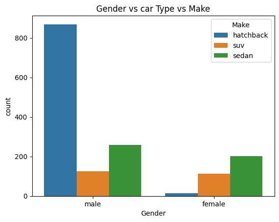

```python
sns.countplot(x="Gender", hue="Make", data=df)
plt.title("Gender vs car Type vs Make")
plt.show()
```

Hatchback is the most wanted for males, where as Sedan is more preferable by Female.

### 6. Dependants and car size:

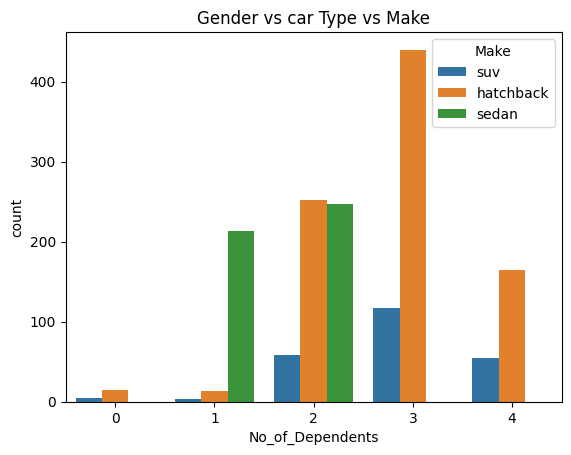

```python
sns.countplot(x="No_of_Dependents", hue="Make", data=df)
plt.title("Gender vs car Type vs Make")
plt.show()
```

Number of dependants does not always go along realisticly with the make of the car.

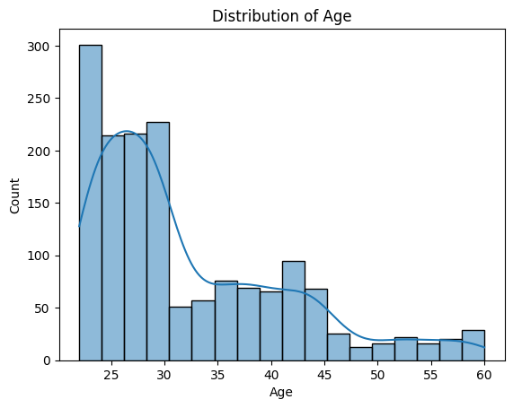

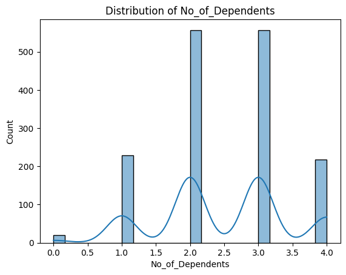

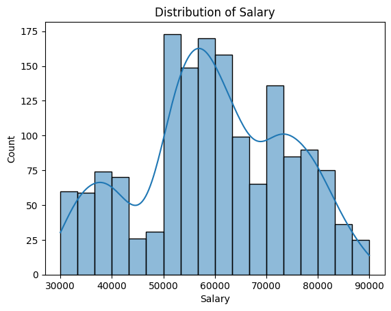

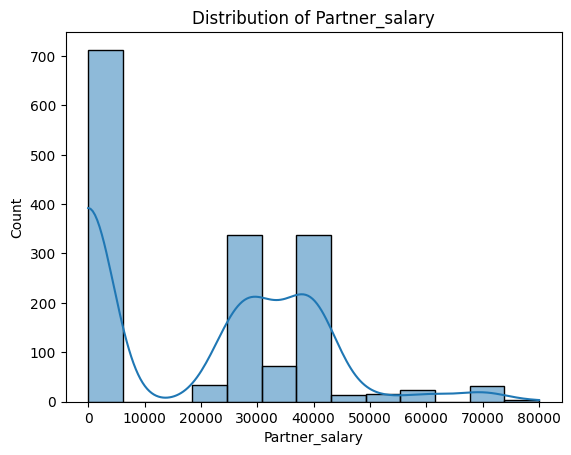

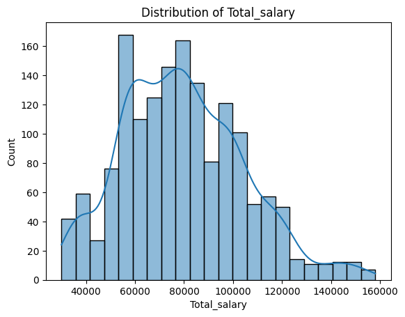

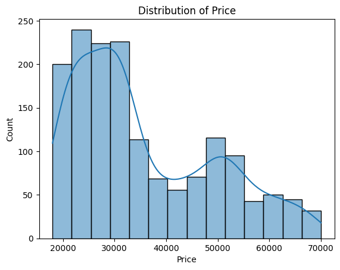

```python
# skewness check:
for col in num_cols:
    sns.histplot(df[col], kde=True)
    plt.title(f"Distribution of {col}")
    plt.show()
```

Age is right swkewd (positive) put it is not require change

```python
df["Total_salary"].skew()
#df["Age"].skew() # Age is right skewed
```

```
np.float64(0.42503424854583693)
```

Skew check showing positive normal skew for total salary and high positive skew for Age but both are normal for both of them due to realistic data.

### Univariate for Categorical Variables:

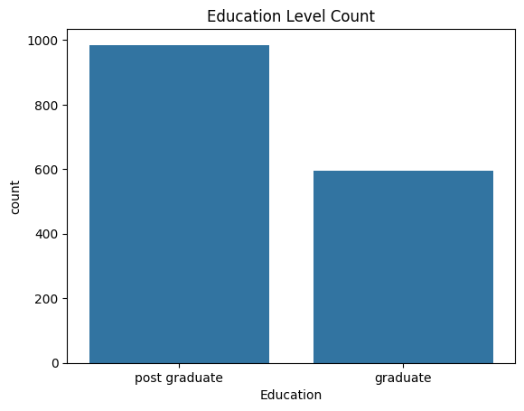

```python
#Count plot for education of the customers
sns.countplot(x="Education", data=df)
plt.title("Education Level Count")
plt.show()
```

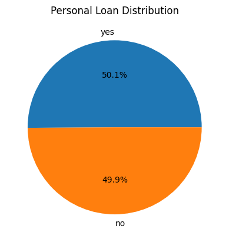

```python
# Pie Chart showing that the customers are split almost equally with loan taking.

df["Personal_loan"].value_counts().plot.pie(autopct="%1.1f%%")
plt.title("Personal Loan Distribution")
plt.ylabel("")
plt.show()
```

### Corelation

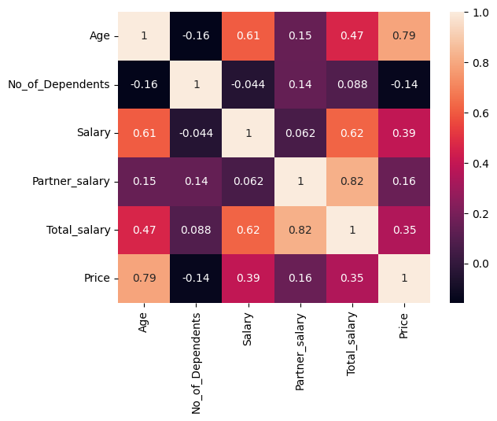

```python
df_corr = df.corr(numeric_only=True)
sns.heatmap(df_corr, annot=True)
plt.show()
```

### Corellation Findings

I suggest to just keep the total salary and drop the both that makes the totla salary.

```python
# Droping The Salary and Partner Salary and Keep Total Salary.
df= df.drop(columns=["Salary","Partner_salary"])
df.columns
```

```
Index(['Age', 'Gender', 'Profession', 'Marital_status', 'Education',
       'No_of_Dependents', 'Personal_loan', 'House_loan', 'Partner_working',
       'Total_salary', 'Price', 'Make'],
      dtype='str')
```

```python
df.head(6)
```

|  | Age | Gender | Profession | Marital_status | Education | No_of_Dependents | Personal_loan | House_loan | Partner_working | Total_salary | Price | Make |
| --- | --- | --- | --- | --- | --- | --- | --- | --- | --- | --- | --- | --- |
| 0 | 24 | male | salaried | married | post graduate | 4 | no | yes | yes | 77000 | 18000 | hatchback |
| 1 | 28 | male | salaried | married | post graduate | 3 | no | yes | no | 68000 | 18000 | hatchback |
| 2 | 23 | male | salaried | married | graduate | 4 | yes | yes | no | 31000 | 18000 | hatchback |
| 3 | 26 | male | business | married | post graduate | 4 | yes | yes | yes | 101000 | 18000 | hatchback |
| 4 | 28 | male | business | married | post graduate | 4 | yes | no | no | 64000 | 18000 | hatchback |
| 5 | 36 | male | salaried | married | post graduate | 3 | yes | no | no | 66000 | 49000 | suv |

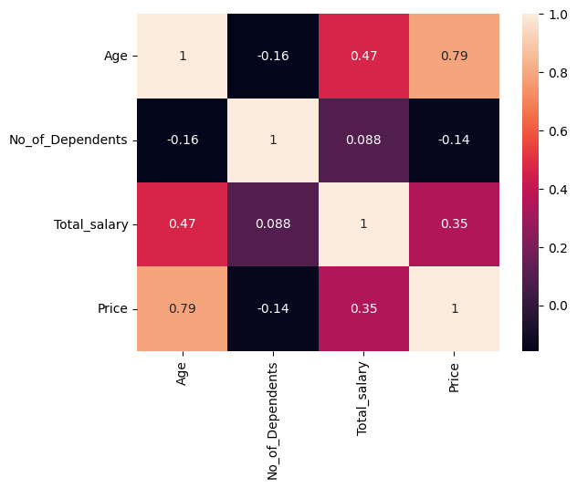

```python
# Corelattion After droping the unwanted salaries
df_corr = df.corr(numeric_only=True)
sns.heatmap(df_corr, annot=True)
plt.show()
```

We still have strong corellation between Age and price which is normal for this ocation .

## Outliers Handeling

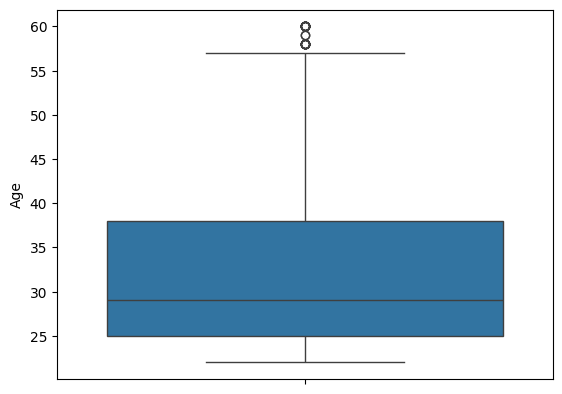

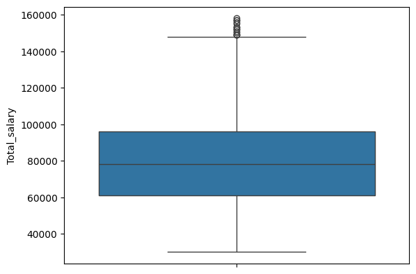

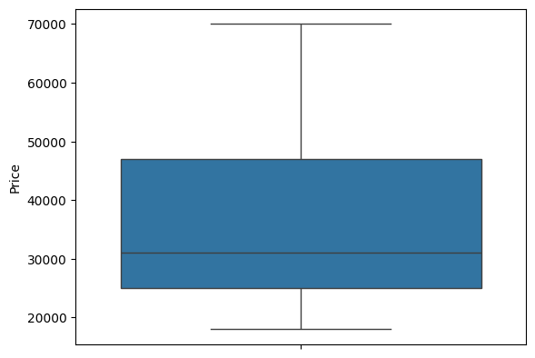

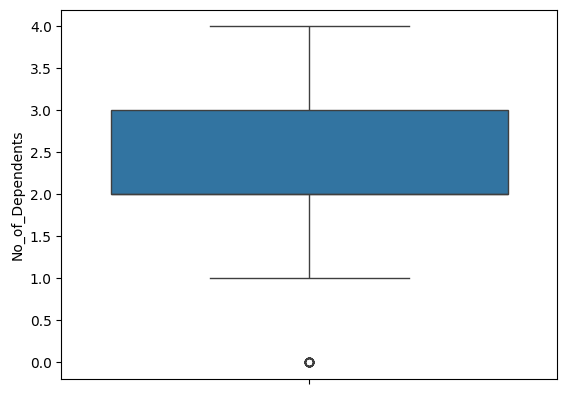

```python
# Boxplot for Outliers

for i in ["Age", "Total_salary", "Price",  "No_of_Dependents"]:
    sns.boxplot(y=df[i])
    plt.show()
```

The outliers that we have do not indecate any mistakes in data entry, they all appear to be real

At the End:  
1. The types of cars preferred by the customers.  
The answer : the most purchaced by male is hatchback and female sedan  
*******************  
2. The Factores influencing the car purchase.  
higher salary means more suv purchased cars  
hached back cars purchased more with more dependents due to low prices. 3. Understand the cars market in U.S.A

Aims of the Analysis:

1. understand the dynamics of a new market.
2. identify new purchase ooportunities  
   intreduce suv more to more famlilies as it is pricers means better revenue and more conveniance to the famlies